# Setting up a particle filter and Particle MCMC

NIMBLE training materials module

NIMBLE Development Team

# Overview

Particle filters (or Sequential Monte Carlo) are a method for simulated approximation of the likelihood of a state-space model.

NIMBLE provides a basic (“bootstrap”) PF, an Auxiliary PF, and a Liu-West filter. The last one attempts to filter parameters as well and is not an algorithm that always works well. Of course these are written as nimbleFunctions so you can look at the R code and then create your own new idea.

In NIMBLE one has the flexibility to compose a Particle MCMC (PMCMC). This method uses MCMC for parameters and a particle filter to evaluate the state-space likelihood needed by the MCMC. Andrieu et al. proved this is valid.

When MCMC of parameters and states works well, it will typically be more efficient that PMCMC. But there is a lot of current research on PMCMC for models with it is not simple to set up MCMC for latent states.

We will show two ways to set up a PMCMC:

1. NIMBLE provides an MCMC sampler already set up to use random-walk Metropolis-Hastings for one or more parameters and evaluate the state-space likelihood using a PF (bootstrap or auxiliary).
2. (Optional) NIMBLE provides an MCMC sampler that allows you to provide *any* other nimbleFunction as the likelihood evaluator. We illustrate this by showing how it can be used to construct a PMCMC at a more fine-grained level than item 1.

# Set up state-space model example

```r
ssmCodeAlt <- nimbleCode({
# Priors and constraints
logN.est[1] ~ dnorm(5.6, 0.01)       # Prior for initial population size
mean.r ~ dnorm(1, 0.001)             # Prior for mean growth rate
sigma.proc ~ dunif(0, 1)             # Prior for sd of state process
sigma.obs ~ dunif(0, 1)              # Prior for sd of observation process

# Likelihood
# State process
for (t in 1:(T-1)){
   logN.est[t+1] ~ dnorm(logN.est[t] + mean.r, sd = sigma.proc)
   }
# Observation process
for (t in 1:T) {
   y[t] ~ dnorm(logN.est[t], sd = sigma.obs)
   }

# Population sizes on real scale
for (t in 1:T) {
   N.est[t] <- exp(logN.est[t])
   }
})

pyears <- 6 # Number of future years with predictions
hm <- c(271, 261, 309, 318, 231, 216, 208, 226, 195, 226, 233, 209, 226, 192, 191, 225,
        245, 205, 191, 174, rep(NA, pyears))
year <- 1990:(2009 + pyears)

# Bundle data
bugs.data <- list(y = log(hm), T = length(year))
## NIMBLE will handle y as data, T as a constant

set.seed(1)
inits <- function(){list(sigma.proc = runif(1, 0, 1), mean.r = rnorm(1),
                         sigma.obs = runif(1, 0, 1), logN.est = c(rnorm(1, 5.6, 0.1),
                                                         rep(NA, (length(year)-1))))}
ssm <- nimbleModel(ssmCodeAlt, constants = bugs.data, inits = inits())
```

```
## defining model...
```

```
## Detected y as data within 'constants'.
## Adding y as data for building model.
```

```
## building model...
```

```
## setting data and initial values...
```

```
## checking model...   (use nimbleModel(..., check = FALSE) to skip model check)
```

```
## NAs were detected in model variables: logN.est, logProb_logN.est, lifted_logNpest_oBt_cB_plus_meanpr, logProb_y, N.est, y.
```

```
## model building finished
```

# Setting up auxiliary particle filter

First we show how a particle filter can be created on its own

```r
## buildAuxiliaryFilter is "just" a nimbleFunction
auxFilterSSM <- buildAuxiliaryFilter(ssm, nodes = 'logN.est')
compiled <- compileNimble(ssm, auxFilterSSM)
compiled$auxFilterSSM$run(10000) ## 10000 is the number of samples
```

```
## [1] -66.82564
```

# Using a particle filter in PMCMC: the easy way

First we show how to use the random-walk PF sampler. We create an empty configuration and then add a sampler for each parameter.

```r
pmcmcConf <- configureMCMC(ssm, nodes = NULL,     # an empty configuration
                           monitors = c('mean.r','sigma.obs','sigma.proc'))
pmcmcConf$addSampler(target = 'mean.r', type = 'RW_PF',
                      control = list(filterType = 'bootstrap', latents = 'logN.est'))
pmcmcConf$addSampler(target = 'sigma.proc', type = 'RW_PF',
                      control = list(filterType = 'bootstrap', latents = 'logN.est'))
pmcmcConf$addSampler(target = 'sigma.obs', type = 'RW_PF',
                      control = list(filterType = 'bootstrap', latents = 'logN.est'))
pmcmc <- buildMCMC(pmcmcConf)
Cpmcmc <- compileNimble(pmcmc, project = ssm, resetFunctions = TRUE)
Cpmcmc$run(1000)
```

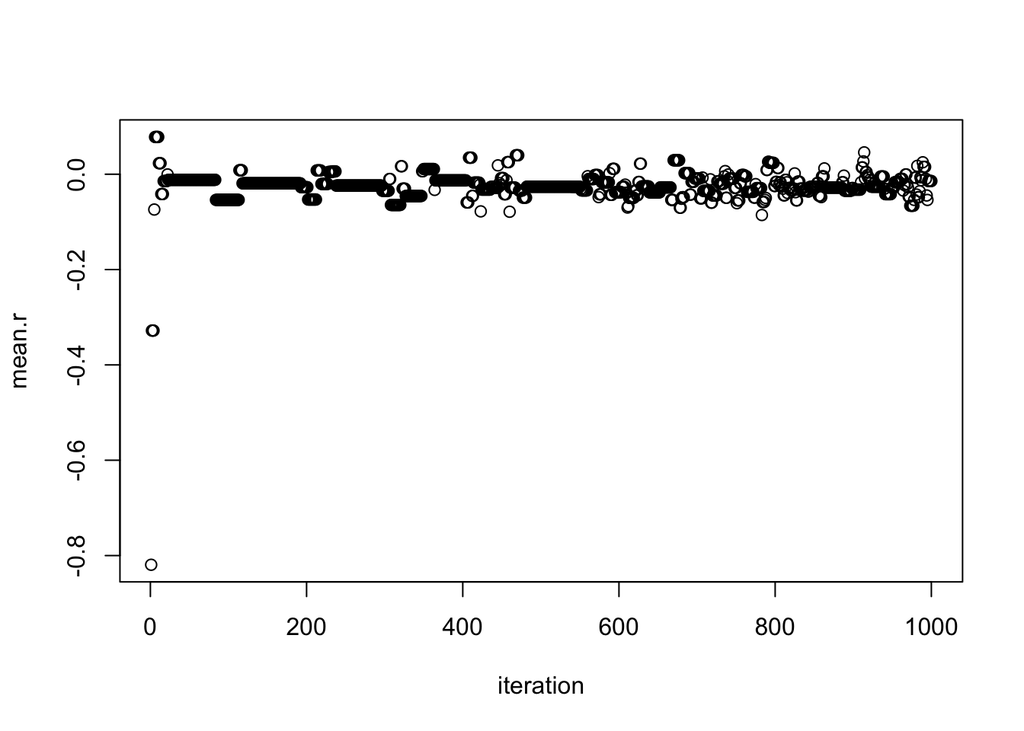

```r
plot(as.matrix(Cpmcmc$mvSamples)[,'mean.r'],
               xlab = 'iteration', ylab = 'mean.r')
```

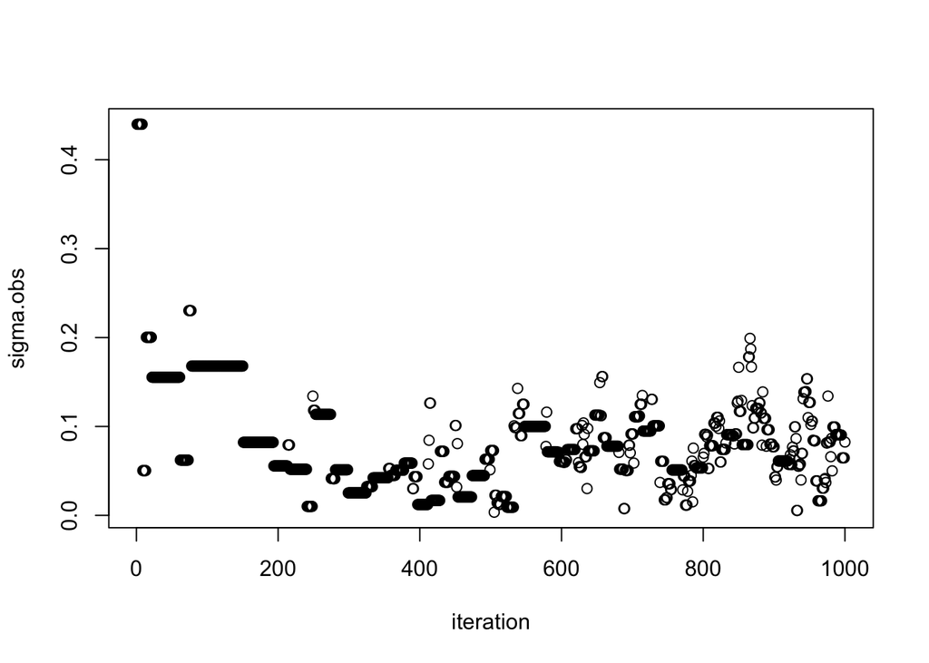

```r
plot(as.matrix(Cpmcmc$mvSamples)[,'sigma.obs'],
               xlab = 'iteration', ylab = 'sigma.obs')
```

It is notable how the mixing is slow until the RW samplers have had some iterations to adapt their proposal scales.